# Projet numéro 3 ( nettoyage )

```python
import pandas as pd
import numpy as np
import missingno as msno
import time
```

### Importons les données

Les données sont libre de droit, et donc utilisable par tout le monde gratuitement.

```python
av = time.time()
data = pd.read_csv('en.openfoodfacts.org.products.csv',sep='	')
ap = time.time()
print('Le dataset a mis',int(100*(ap-av))/100,"secondes à s'ouvrir.")
```

```
Le dataset a mis 85.49 secondes à s'ouvrir.
```

###### Stockage

La base de données est assez lourde : 3,09 Go

###### Source des données

Les données ont été rentrées par des dizaines de milliers de bénévoles comme vous et moi, pour contribuer à l'évolution de cette base de données.

# Données brutes

```python
data.shape
```

```
(1469560, 181)
```

### Lignes

Les 1469560 lignes correspondent à tous les produits alimentaires.

```python
a = data['code'].count()
b = len(data['code'].unique())

print('Le nombre de lignes dont le code est valide est de :',a,'valeurs.')
print('Le nombre de code est de :',b,'valeurs.')
print('Il y a donc',a-b,'doublons.')
```

```
Le nombre de lignes dont le code est valide est de : 1469560 valeurs.
Le nombre de code est de : 1469221 valeurs.
Il y a donc 339 doublons.
```

###### Enlevons les doublons

```python
data = data.drop_duplicates(subset = 'code')
```

### Colonnes

Les 181 colonnes correspondent à tous les indicateurs qui définissent le produit alimentaire :

- Les informations générales sur la fiche du produit : nom, date de modification, etc.
- Un ensemble de tags : catégorie du produit, localisation, origine, etc.
- Les ingrédients composant les produits et leurs additifs éventuels.
- Des informations nutritionnelles : quantité en grammes d’un nutriment pour 100 grammes du produit.

Les variables pertinentes pour notre objectif sont :

- Code de chaque produit
- Le pays de commercialisation
- Les catégories
- Le nombre d'additifs
- Protéines pour 100g
- Sucres pour 100g
- Matières grasses pour 100g
- Groupe NOVA
- Groupe PNNS 1
- Nutri Score grade (A -> E)

# Nettoyons notre jeu de données

```python
def clean_data_columns(data, columns):
    data = data.loc[:,columns]
    return data

def clean_data_index(data, index, choice_of_index):
    data = data[data[index] == choice_of_index]
    return data
```

### Filtrons les colonnes intéressantes

```python
columns = ['code','countries_tags','main_category','labels','additives_n','proteins_100g','sugars_100g',
           'fat_100g','nova_group','pnns_groups_1','nutriscore_grade']

data_clean = clean_data_columns(data, columns)
```

### Choisissons les aliments commercialisés en France

```python
data_clean = clean_data_index(data_clean, index='countries_tags', choice_of_index='en:france')
```

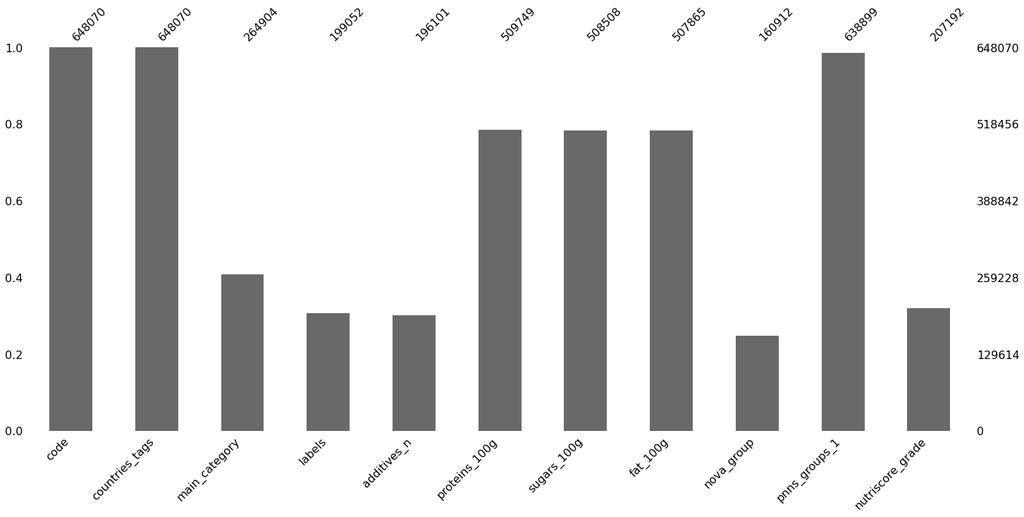

```python
msno.bar(data_clean)
```

```python
def valeursManquantes(data):
    for column in data.columns:
        nb = data[column].count()
        n = data.shape[0]
        print('Nombre de valeurs valides de',column,':',nb,'(',int((1000*nb/n))/10,'%)')

valeursManquantes(data_clean)
```

```
Nombre de valeurs valides de code : 648070 ( 100.0 %)
Nombre de valeurs valides de countries_tags : 648070 ( 100.0 %)
Nombre de valeurs valides de main_category : 264904 ( 40.8 %)
Nombre de valeurs valides de labels : 199052 ( 30.7 %)
Nombre de valeurs valides de additives_n : 196101 ( 30.2 %)
Nombre de valeurs valides de proteins_100g : 509749 ( 78.6 %)
Nombre de valeurs valides de sugars_100g : 508508 ( 78.4 %)
Nombre de valeurs valides de fat_100g : 507865 ( 78.3 %)
Nombre de valeurs valides de nova_group : 160912 ( 24.8 %)
Nombre de valeurs valides de pnns_groups_1 : 638899 ( 98.5 %)
Nombre de valeurs valides de nutriscore_grade : 207192 ( 31.9 %)
```

```python
data_clean.dropna().shape[0]
```

```
68331
```

Le dataframe contient 68331 aliments qui contiennent toutes les valeurs, ce qui nous suffit pour l'analyse exploratoire.

```python
prop = int(10000*data_clean.dropna().shape[0]/data_clean.shape[0])/100
print('Parmi tous les aliments vendu en France, il y a',prop,"% d'aliments qui n'a pas de valeurs manquantes.")
```

```
Parmi tous les aliments vendu en France, il y a 10.54 % d'aliments qui n'a pas de valeurs manquantes.
```

```python
data_clean = data_clean.dropna()
data_clean.index = np.arange(0,data_clean.shape[0])
```

```python
data[data['countries_tags'] == 'en:france']['main_category'].unique().shape
```

```
(13648,)
```

```python
data_clean['main_category'].unique().shape
```

```
(6802,)
```

# Enregistrons le dataset nettoyé en fichier csv

```python
data_clean.to_csv(r'/Users/samuelcoulomb/Desktop/data_nettoyer.csv')
```